### Scripts

```r
source("Variable importance assessment.R", local = knitr::knit_global())
source("Predictive performance assessment.R", local = knitr::knit_global())
source("Statistical analysis.R", local = knitr::knit_global())
```

### Dataset

```r
PB_predictors_data <- read.csv("Data/Phase behaviour and descriptors (25 pc step).csv")
```

The dataset was split into a training/testing (`TT_data`) and validation subset comprising 21 and 7 phase diagrams, respectively. Only the training/testing dataset was used to determine the importance of the different predictors in the random forest models.

```r
TT_data <- filter(PB_predictors_data, Set == "Training")
```

A list of all phase behaviour predictor names was created and the phase behaviour variable was encoded as a factor.

```r
predictors_all <- colnames(TT_data[, 3:66][, -(4:6)])
TT_data$Phase.behaviour <- factor(as.character(TT_data$Phase.behaviour))
```

### Variables importance

#### Determination of variables importance

To quantify the importance of the different compositional and molecular descriptors, 20 random forest models comprising 50 decision trees each were trained using a randomly selected 70% of the `TT_data`, *i.e.*, the training data, and their predictive performance on the remaining 30% of the `TT_data`, *i.e.*, the testing data, as well as the *importance of each variable* in each structure was determined.

```r
for (i in 1:20) {
    model_performance_varimp <- run_random_forest(TT_data, predictors_all, model_performance_varimp,
        "RF - all predictors", i)
}
```

#### Comparison of variables importance

To compare the overall importance of the different variables for the random forest models, the scalled importance of each variable was averaged over the 20 resampled runs.

The results suggest that only three variables have an average scaled variable importance higher than 10: the PS, NPS and SPC concentration, *i.e.*, the variables that define the compostion of each nonaqueous sample.

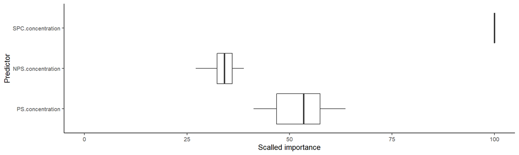

The remaining 58 predictors, *i.e.*, the solvent molecular descriptors, all have an average scaled importance lower than 10.

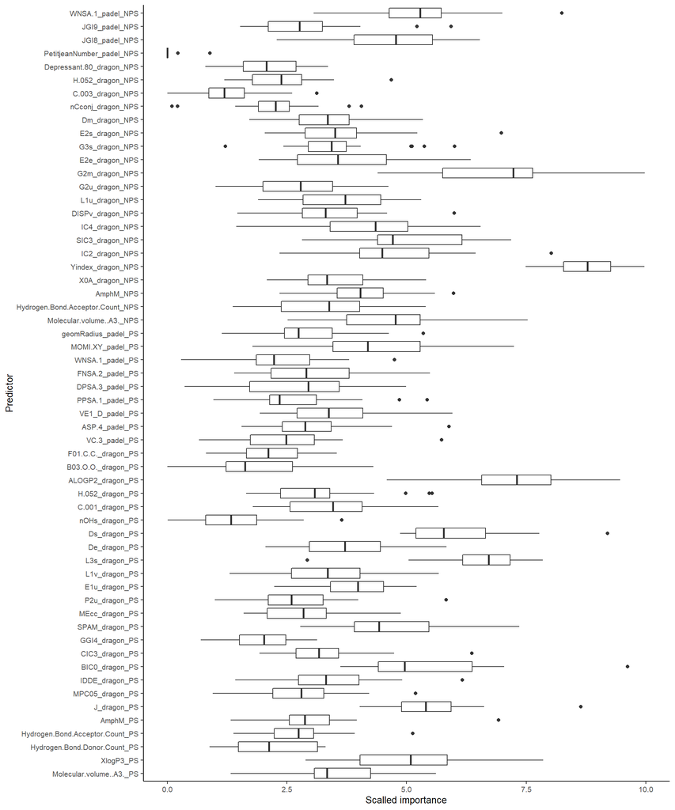

Despite the average scaled importance of all molecular descriptors being relatively low, many of the differences between their importances are statistically significant as illustrated in the binary plot below, where statistically significant differences (p ≤ 0.05) are shown as *1s* (Blue) and non-statistically significant differences (p > 0.05) as *-1s* (Red).

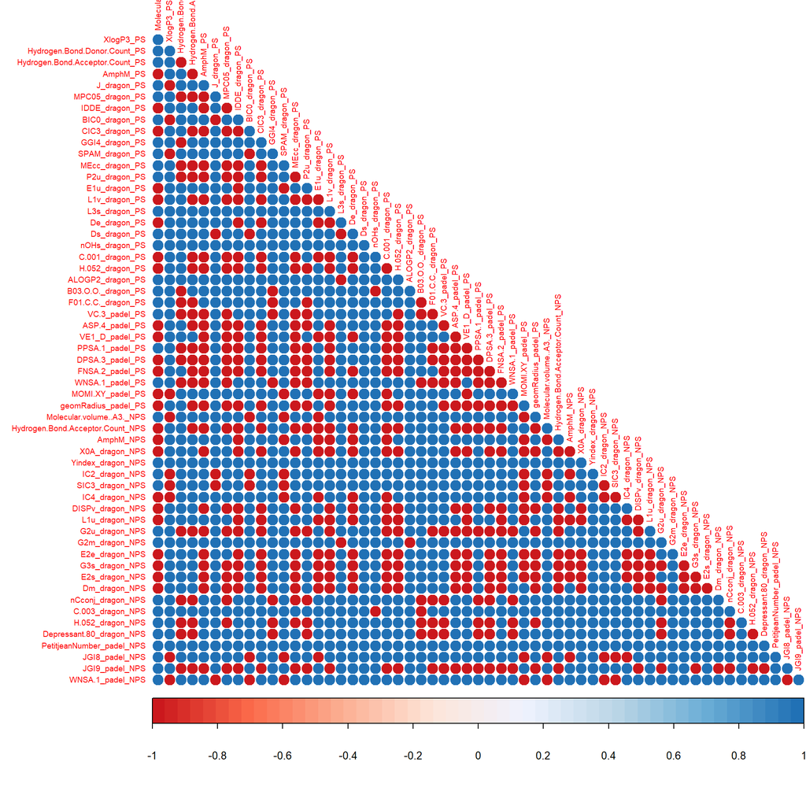

Interestingly, the results suggest that the importance of *Yindex_dragon_NPS* is significantly higher than that of all the remaining molecular descriptors, while *ALOGP2_dragon_PS* has a significantly higher variable importance than all other polar solvent (PS) molecular descriptors.

The predictors ranking by importance is as follows:

```
##  [1] "SPC.concentration"                "PS.concentration"
##  [3] "NPS.concentration"                "Yindex_dragon_NPS"
##  [5] "ALOGP2_dragon_PS"                 "G2m_dragon_NPS"
##  [7] "L3s_dragon_PS"                    "Ds_dragon_PS"
##  [9] "J_dragon_PS"                      "BIC0_dragon_PS"
## [11] "WNSA.1_padel_NPS"                 "XlogP3_PS"
## [13] "SIC3_dragon_NPS"                  "IC2_dragon_NPS"
## [15] "Molecular.volume..A3._NPS"        "SPAM_dragon_PS"
## [17] "JGI8_padel_NPS"                   "MOMI.XY_padel_PS"
## [19] "IC4_dragon_NPS"                   "AmphM_NPS"
## [21] "E1u_dragon_PS"                    "L1u_dragon_NPS"
## [23] "De_dragon_PS"                     "E2e_dragon_NPS"
## [25] "Molecular.volume..A3._PS"         "E2s_dragon_NPS"
## [27] "G3s_dragon_NPS"                   "X0A_dragon_NPS"
## [29] "C.001_dragon_PS"                  "IDDE_dragon_PS"
```

[output cut: 16 more lines]

### Random forest employing predictor subsets selected using variable importance

To determine the effect of using a subset of the variables of highest importance to train the models on the predictive performance of the random forest algorithm, models employing subsets of the highest *2x + 1* ranking variables (*x = 1 to 29*) were trained using the 70% of `TT_data` and evaluted on the remaining 30% of `TT_data` (n = 10).

```r
for (i in 1:29) {
    for (j in 1:10) {
        predictor_last = 2 * i + 1
        model_number = (i - 1) * 10 + j
        model_name = paste("RF", predictor_last)
        model_performance_varimp_ordered_pred <- run_random_forest(TT_data, predictors_ordered_varimp_list[1:predictor_last],
            model_performance_varimp_ordered_pred, model_name, model_number)
    }
}
```

#### Visual comparison

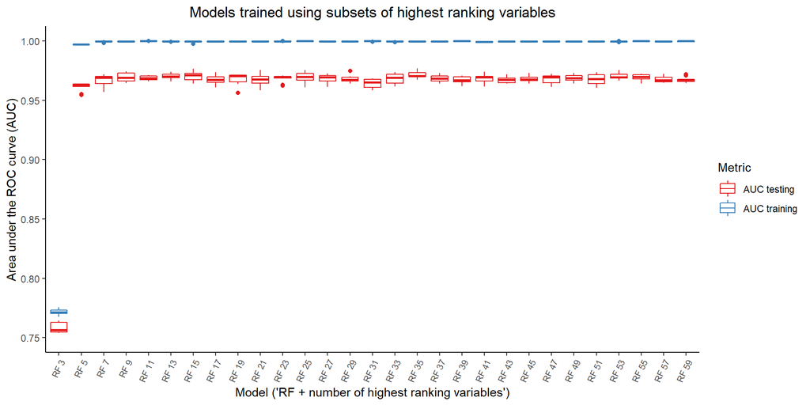

#### Statistical comparison

To help visualise the statistical significance of the differences in the generalisation abilities between the 29 random forest models, binary plot, where statistically significant differences (p ≤ 0.05) are shown as *1s* (Blue) and non-statistically significant differences (p > 0.05) as *-1s* (Red), were employed.

##### Binary plot comparison of AUC values achieved on the training data by random forest models employing predictor subsets

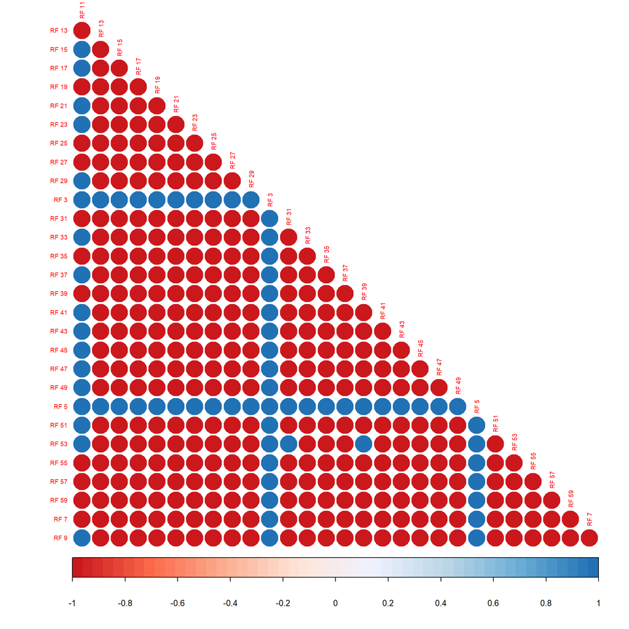

##### Binary plot comparison of AUC values achieved on the testing data by random forest models employing predictor subsets

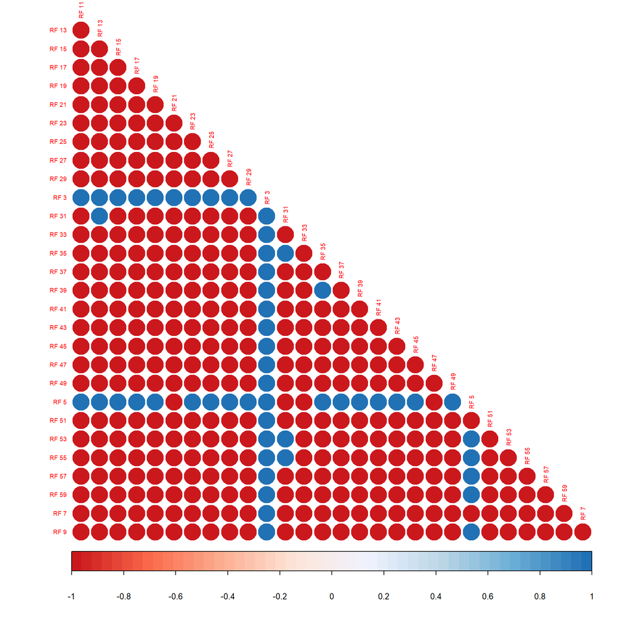

**Overall, the above results suggest that employing subsets of compositional and molecular descriptors results in predominantly marginal changes in the predictive performance of the models on both the training and testing data.**

**Overall, the results did not allow for a single combination of predictors to be identified as optimal, however, they do suggest that there is room for improvement in the selection of features used to train the random forest models and potential for generalisation abilities imrpovement based on it.**